# Akshay Jagadeesh, Homework 1

Load packages you’ll be using throughout the HW

```r
library(ggplot2)
```

## Question 1

### Q1 Part A

```r
d0 = c(26, 31, 45)
rs1 = chisq.test(d0, p=c(1, 1, 1), rescale.p=T, simulate.p.value=F)
print(rs1)
```

```
##
##  Chi-squared test for given probabilities
##
## data:  d0
## X-squared = 5.7059, df = 2, p-value = 0.05767
```

### Q1 Part B-i

```r
deaths = c(11, 15, 15, 16, 25, 20)
mean_deaths = mean(deaths)
sd_deaths = sd(deaths)
var_deaths = var(deaths)
print(mean_deaths)
```

```
## [1] 17
```

```r
print(sd_deaths)
```

```
## [1] 4.857983
```

```r
print(var_deaths)
```

```
## [1] 23.6
```

The mean of this sample is 17, indicating that from 1990 to 1995, 17 juveniles died from maltreatment on average yearly. The standard deviation of these juvenile maltreatment deaths was 4.8579831, and the variance of this sample was 23.6.

### Q1 Part B-ii

```r
se_deaths = sd_deaths / sqrt(length(deaths))
print(se_deaths)
```

```
## [1] 1.983263
```

The standard error of this sample of juvenile deaths from 1990 to 1995 is 1.9832633.

### Q1 Part B-iii

Assuming no trend and $\bar{x}$ = 17, we derive the algebraic expression for the estimated number of deaths, *T*, over *k* years by the equation:

T = 17 * k

This is a linear function of $\bar{x}$, which assumes that on average 17 juveniles die of maltreatment each year, so after *k* years, we estimate that the total number of juvenile deaths (T) will equal 17*k*.

### Q1 Part B-iv

The standard deviation of T will be equal to *k* times the standard deviation of $\bar{x}$.

sd(T) = k * sd({x}) = k * SE(x) = k * 1.9832633

### Q1 Part B-v

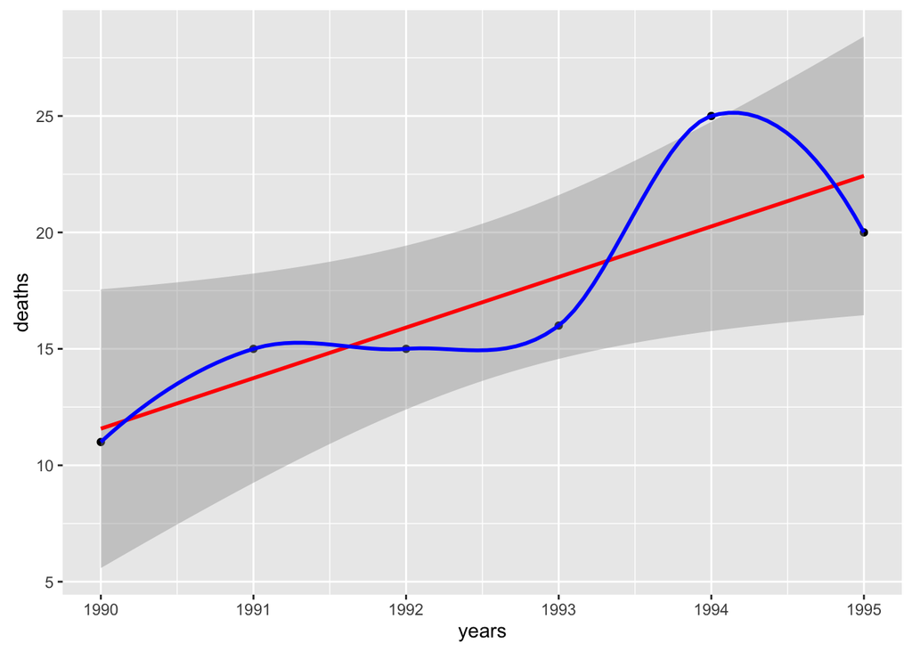

```r
deathDF = data.frame(years=c(1990,1991,1992,1993,1994,1995), deaths)
ggplot(deathDF, aes(x=years, y=deaths)) +
  geom_point() + geom_smooth(method=lm, colour="red") +
  geom_smooth(method=loess, colour="blue")
```

The red line is the linear regression fit of the data, and the blue line is the Loess curve.

## Question 2

### Q2 Part A

```r
earlyDeaths = read.csv("earlydeaths.csv")
deathTab <- table(factor(earlyDeaths$cause), factor(earlyDeaths$time))
deathTab <- cbind(deathTab, Total = rowSums(deathTab))
deathTab <- rbind(deathTab, Total = colSums(deathTab))
deathTab
```

```
##        1   2   3 Total
## 1     26  31  45   102
## 2     68  80 100   248
## Total 94 111 145   350
```

### Q2 Part B

### Q2 Part C

## Question 9

### Q9 Part A

First, we calculated the mean of the non-normal distribution `D0`.

```r
x0 = c(1:3, 5, 7, 9)
p0 = c(.2, .4, .24, .10, .05, .01)
mu0 = sum(x0 * p0) / sum(p0)
print(mu0)
```

```
## [1] 2.66
```

The mean of `D0` is 2.66.

**Instructor’s Note:** You could also write your narrative text as follows, which will ensure that the number you report is always in sync with the code you wrote. This is a bit more complex, but recommended:

The mean of `D0` is 2.66.

### Q9 Part B

Next, we drew a sample of 1000 observations from the skewed distribution `x0`.

```r
o1 = sample(x0, 1000, replace=T, prob = p0)
```

Then, we made a histogram of `x0` along with the estimated probability density function.

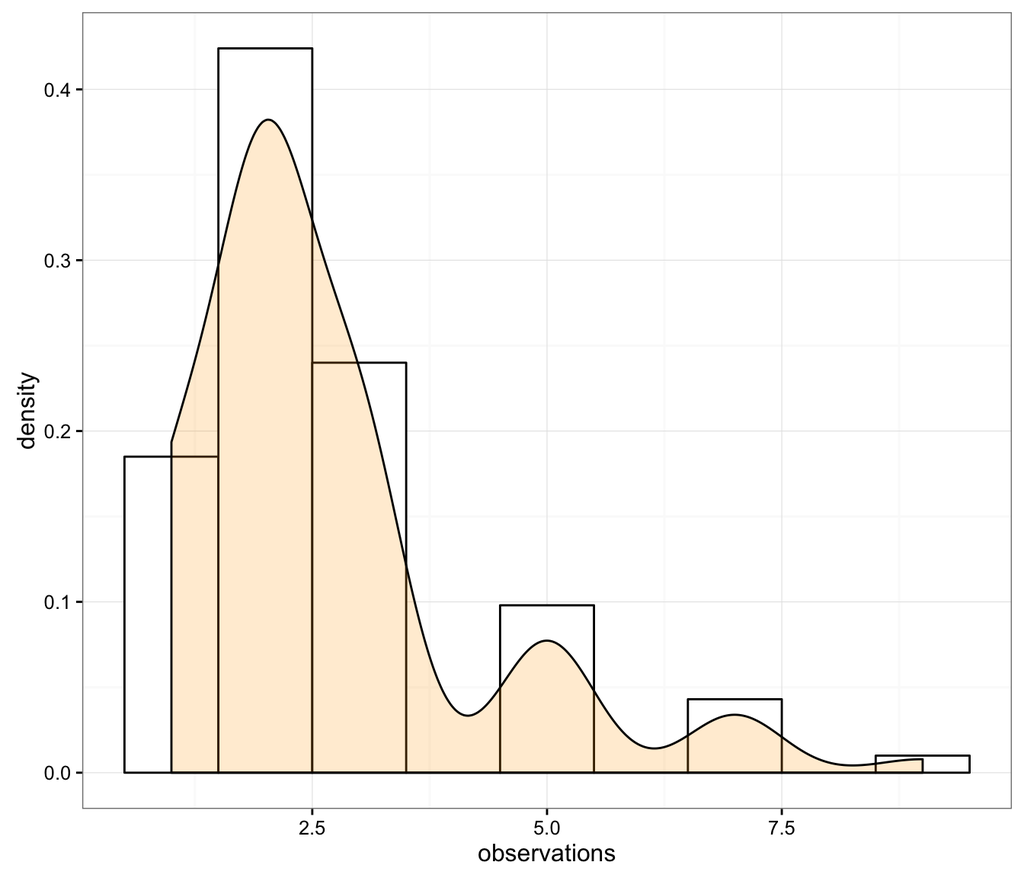

```r
df = data.frame(observations=o1)

ggplot(df, aes(x=observations)) +
  geom_histogram(aes(y=..density..), #..density.. normalizes the y axis to the density (i.e. counts / total)
                 color='black',
                 fill='white',
                 binwidth=1,
                 breaks=c(0.5:9.5)) + # see ?geom_histogram for details
  geom_density(alpha=0.2,
               fill='orange',
               adjust=3) +
  theme_bw()
```

```r
## If you prefer plotting without ggplot, you can use this code:

# rs1 = hist(o1, prob=T, main='Sampling distribution of x0, 1000 Samples')
# lines(density(o1, adjust=3))
```

## Question 10: (example stats writeup)

Here we have some data (`x0`) about the demographics of participants in our experiment. We also have some data (`p0`) about the distribution of races in the United States.

We want to know whether the distribution of races in our data is consistent with the specified US distribution.

```r
x0 = c(white=273, black=40, asian=10, other=5)
p0 = c(white=.77, black=.13, asian=.054, other=0.046)

# calculate proportions in sample
x0/sum(x0)
```

```
##     white     black     asian     other
## 0.8323171 0.1219512 0.0304878 0.0152439
```

#### Conduct a chi-squared test

```r
rs = chisq.test(x0, p=p0)
rs
```

```
##
##  Chi-squared test for given probabilities
##
## data:  x0
## X-squared = 11.921, df = 3, p-value = 0.00766
```

```r
rs$expected
```

```
##   white   black   asian   other
## 252.560  42.640  17.712  15.088
```

Running a $X^2$ goodness-of-fit test, we see that we reject the null hypothesis that the distribution of races in our data is consistent with the US distribution, $X^2$ (3, N=328) =11.9205229, p = 0.0076604. Thus, it appears that our data is not consistent with the US distribution. Specifically, we have more white participants than we would have expected (273 (~83%), relative to 253 if 77% of our participants were white), and we have fewer asian and other participants than would have been expected (approximately 10 fewer, off by about 3%). Perhaps we sampled from a college that had a larger proportion of white students relative to the US population, and as a result our sample was biased.